# An In Depth Look at Shooting Incidents in NYC

Steven Lee

2023-10-14

Per the data.gov website, this data is a list of every shooting incident in NYC from 2006 to the previous calendar year. The Office of Management Analysis and Planning manually extract and review this data before posting. Every record is represented by each shooting incident and its related information.

## Library Used

```r
library(tidyverse)
library(lubridate)
```

## Import Data

Import NYPD Shooting Incident data by the given URL as a .csv file.

```r
url <- "https://data.cityofnewyork.us/api/views/833y-fsy8/rows.csv?accessType=DOWNLOAD"
shootings_data_raw <- read_csv(url,show_col_types = FALSE)
head(shootings_data_raw)
```

```
## # A tibble: 6 × 21
##   INCIDENT_KEY OCCUR_DATE OCCUR_TIME BORO     LOC_OF_OCCUR_DESC PRECINCT
##          <dbl> <chr>      <time>     <chr>    <chr>                <dbl>
## 1    228798151 05/27/2021 21:30      QUEENS   <NA>                   105
## 2    137471050 06/27/2014 17:40      BRONX    <NA>                    40
## 3    147998800 11/21/2015 03:56      QUEENS   <NA>                   108
## 4    146837977 10/09/2015 18:30      BRONX    <NA>                    44
## 5     58921844 02/19/2009 22:58      BRONX    <NA>                    47
## 6    219559682 10/21/2020 21:36      BROOKLYN <NA>                    81
## # ℹ 15 more variables: JURISDICTION_CODE <dbl>, LOC_CLASSFCTN_DESC <chr>,
## #   LOCATION_DESC <chr>, STATISTICAL_MURDER_FLAG <lgl>, PERP_AGE_GROUP <chr>,
## #   PERP_SEX <chr>, PERP_RACE <chr>, VIC_AGE_GROUP <chr>, VIC_SEX <chr>,
## #   VIC_RACE <chr>, X_COORD_CD <dbl>, Y_COORD_CD <dbl>, Latitude <dbl>,
## #   Longitude <dbl>, Lon_Lat <chr>
```

```r
summary(shootings_data_raw)
```

```
##   INCIDENT_KEY        OCCUR_DATE         OCCUR_TIME           BORO
##  Min.   :  9953245   Length:27312       Length:27312      Length:27312
##  1st Qu.: 63860880   Class :character   Class1:hms        Class :character
##  Median : 90372218   Mode  :character   Class2:difftime   Mode  :character
##  Mean   :120860536                      Mode  :numeric
##  3rd Qu.:188810230
##  Max.   :261190187
##
##  LOC_OF_OCCUR_DESC     PRECINCT      JURISDICTION_CODE LOC_CLASSFCTN_DESC
##  Length:27312       Min.   :  1.00   Min.   :0.0000    Length:27312
##  Class :character   1st Qu.: 44.00   1st Qu.:0.0000    Class :character
##  Mode  :character   Median : 68.00   Median :0.0000    Mode  :character
##                     Mean   : 65.64   Mean   :0.3269
##                     3rd Qu.: 81.00   3rd Qu.:0.0000
##                     Max.   :123.00   Max.   :2.0000
##                                      NA's   :2
##  LOCATION_DESC      STATISTICAL_MURDER_FLAG PERP_AGE_GROUP
##  Length:27312       Mode :logical           Length:27312
##  Class :character   FALSE:22046             Class :character
##  Mode  :character   TRUE :5266              Mode  :character
##
##
##
##
##    PERP_SEX          PERP_RACE         VIC_AGE_GROUP        VIC_SEX
##  Length:27312       Length:27312       Length:27312       Length:27312
##  Class :character   Class :character   Class :character   Class :character
##  Mode  :character   Mode  :character   Mode  :character   Mode  :character
##
##
##
##
##    VIC_RACE           X_COORD_CD        Y_COORD_CD        Latitude
##  Length:27312       Min.   : 914928   Min.   :125757   Min.   :40.51
##  Class :character   1st Qu.:1000029   1st Qu.:182834   1st Qu.:40.67
##  Mode  :character   Median :1007731   Median :194487   Median :40.70
##                     Mean   :1009449   Mean   :208127   Mean   :40.74
##                     3rd Qu.:1016838   3rd Qu.:239518   3rd Qu.:40.82
##                     Max.   :1066815   Max.   :271128   Max.   :40.91
##                                                        NA's   :10
##    Longitude        Lon_Lat
##  Min.   :-74.25   Length:27312
##  1st Qu.:-73.94   Class :character
##  Median :-73.92   Mode  :character
##  Mean   :-73.91
##  3rd Qu.:-73.88
##  Max.   :-73.70
##  NA's   :10
```

## Data Clean Up

I clean the raw data to include standardized occurrence dates along with the New York location where the incident occurred. Select only the necessary columns and other missing data that are not related with this report are removed. The resulting data is stored as ‘df_shootings’.

```r
df_shootings <- shootings_data_raw %>% select(INCIDENT_KEY, OCCUR_DATE, OCCUR_TIME, BORO, PERP_AGE_GROUP, PERP_SEX, PERP_RACE, VIC_AGE_GROUP, VIC_SEX, VIC_RACE, Latitude, Longitude) %>% drop_na()
df_shootings$OCCUR_DATE <- mdy(df_shootings$OCCUR_DATE)

summary(df_shootings)
```

```
##   INCIDENT_KEY         OCCUR_DATE          OCCUR_TIME           BORO
##  Min.   :  9953245   Min.   :2006-01-01   Length:17958      Length:17958
##  1st Qu.: 49834899   1st Qu.:2008-08-05   Class1:hms        Class :character
##  Median : 81778268   Median :2011-11-17   Class2:difftime   Mode  :character
##  Mean   :112574247   Mean   :2013-05-10   Mode  :numeric
##  3rd Qu.:178508294   3rd Qu.:2018-04-22
##  Max.   :261190187   Max.   :2022-12-31
##  PERP_AGE_GROUP       PERP_SEX          PERP_RACE         VIC_AGE_GROUP
##  Length:17958       Length:17958       Length:17958       Length:17958
##  Class :character   Class :character   Class :character   Class :character
##  Mode  :character   Mode  :character   Mode  :character   Mode  :character
##
##
##
##    VIC_SEX            VIC_RACE            Latitude       Longitude
##  Length:17958       Length:17958       Min.   :40.52   Min.   :-74.23
##  Class :character   Class :character   1st Qu.:40.67   1st Qu.:-73.94
##  Mode  :character   Mode  :character   Median :40.71   Median :-73.91
##                                        Mean   :40.74   Mean   :-73.91
##                                        3rd Qu.:40.83   3rd Qu.:-73.88
##                                        Max.   :40.91   Max.   :-73.71
```

## Transforming

```r
df_shootings <- df_shootings %>% mutate(VIC_RACE = case_when(VIC_RACE == "American Indian/Alaskan Native" ~ "Native American", VIC_RACE == "Asian / Pacific Islander" ~ "Asian", TRUE ~ VIC_RACE))

df_shootings = df_shootings %>%
  replace_na(list(PERP_AGE_GROUP = "Unknown", PERP_SEX = "Unknown", PERP_RACE = "Unknown"))

df_shootings$PERP_AGE_GROUP = recode(df_shootings$PERP_AGE_GROUP, UNKNOWN = "Unknown")
df_shootings$PERP_SEX = recode(df_shootings$PERP_SEX, U = "Unknown")
df_shootings$PERP_RACE = recode(df_shootings$PERP_RACE, UNKNOWN = "Unknown")
df_shootings$VIC_SEX   = recode(df_shootings$VIC_SEX, U = "Unknown")
df_shootings$VIC_RACE   = recode(df_shootings$VIC_RACE, UNKNOWN = "Unknown")
df_shootings$INCIDENT_KEY = as.character(df_shootings$INCIDENT_KEY)
df_shootings$BORO = as.factor(df_shootings$BORO)
df_shootings$PERP_AGE_GROUP = as.factor(df_shootings$PERP_AGE_GROUP)
df_shootings$PERP_SEX = as.factor(df_shootings$PERP_SEX)
df_shootings$PERP_RACE = as.factor(df_shootings$PERP_RACE)
df_shootings$VIC_AGE_GROUP = as.factor(df_shootings$VIC_AGE_GROUP)
df_shootings$VIC_SEX = as.factor(df_shootings$VIC_SEX)
df_shootings$VIC_RACE = as.factor(df_shootings$VIC_RACE)


summary(df_shootings)
```

```
##  INCIDENT_KEY         OCCUR_DATE          OCCUR_TIME                  BORO
##  Length:17958       Min.   :2006-01-01   Length:17958      BRONX        :5425
##  Class :character   1st Qu.:2008-08-05   Class1:hms        BROOKLYN     :6638
##  Mode  :character   Median :2011-11-17   Class2:difftime   MANHATTAN    :2538
##                     Mean   :2013-05-10   Mode  :numeric    QUEENS       :2726
##                     3rd Qu.:2018-04-22                     STATEN ISLAND: 631
##                     Max.   :2022-12-31
##
##  PERP_AGE_GROUP    PERP_SEX              PERP_RACE     VIC_AGE_GROUP
##  18-24  :6219   (null) :  635   BLACK         :11429   <18    :2027
##  25-44  :5686   F      :  424   WHITE HISPANIC: 2339   1022   :   1
##  Unknown:3148   M      :15434   Unknown       : 1802   18-24  :6513
##  <18    :1590   Unknown: 1465   BLACK HISPANIC: 1314   25-44  :7934
##  (null) : 635                   (null)        :  635   45-64  :1290
##  45-64  : 617                   WHITE         :  283   65+    : 137
##  (Other):  63                   (Other)       :  156   UNKNOWN:  56
##     VIC_SEX                                VIC_RACE        Latitude
##  F      : 1920   AMERICAN INDIAN/ALASKAN NATIVE:    8   Min.   :40.52
##  M      :16030   ASIAN / PACIFIC ISLANDER      :  307   1st Qu.:40.67
##  Unknown:    8   BLACK                         :12246   Median :40.71
##                  BLACK HISPANIC                : 1798   Mean   :40.74
##                  Unknown                       :   48   3rd Qu.:40.83
##                  WHITE                         :  552   Max.   :40.91
##                  WHITE HISPANIC                : 2999
##    Longitude
##  Min.   :-74.23
##  1st Qu.:-73.94
##  Median :-73.91
##  Mean   :-73.91
##  3rd Qu.:-73.88
##  Max.   :-73.71
##
```

I think it’s interesting to look at a cumulative graph of all incidents in all of NY as well as each of the Boroughs over time to see if we can observe any trends in this aspect.

```r
ts_df_shootings <- df_shootings %>% group_by(OCCUR_DATE) %>% summarise(COUNT=n()) %>% ungroup()

summary(ts_df_shootings)
```

```
##    OCCUR_DATE             COUNT
##  Min.   :2006-01-01   Min.   : 1.000
##  1st Qu.:2009-08-14   1st Qu.: 1.000
##  Median :2013-11-01   Median : 3.000
##  Mean   :2014-02-26   Mean   : 3.582
##  3rd Qu.:2018-08-18   3rd Qu.: 5.000
##  Max.   :2022-12-31   Max.   :25.000
```

```r
bronx_n <- df_shootings %>% filter(BORO == "BRONX") %>% group_by(OCCUR_DATE) %>% summarise(COUNT=n()) %>% ungroup()
brooklyn_n <- df_shootings %>% filter(BORO == "BROOKLYN") %>% group_by(OCCUR_DATE) %>% summarise(COUNT=n()) %>% ungroup()
manhattan_n <- df_shootings %>% filter(BORO == "MANHATTAN") %>% group_by(OCCUR_DATE) %>% summarise(COUNT=n()) %>% ungroup()
queens_n <- df_shootings %>% filter(BORO == "QUEENS") %>% group_by(OCCUR_DATE) %>% summarise(COUNT=n()) %>% ungroup()
staten_n <-df_shootings %>% filter(BORO == "STATEN ISLAND") %>% group_by(OCCUR_DATE) %>% summarise(COUNT=n()) %>% ungroup()
```

## Visualizations

Now that all the data is organized, we can make some visualizations for questions we want answered.

1. Which victim is race is involved in the most incidents?

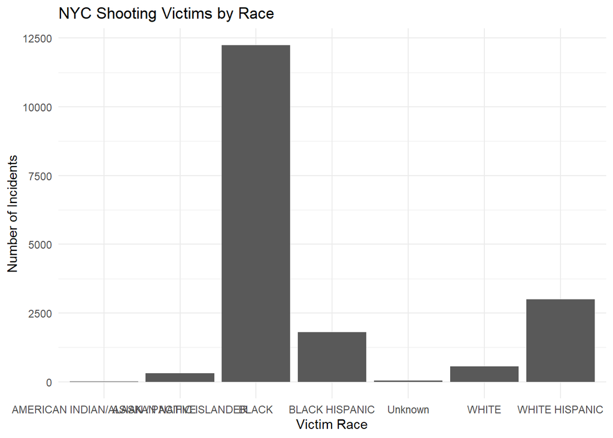

```r
ggplot(df_shootings, aes(x = VIC_RACE)) +
  geom_bar() +
  labs(title = "NYC Shooting Victims by Race",
       x = "Victim Race",
       y = "Number of Incidents") +
  theme_minimal()
```

We can see that shooting incidents most often involve blacks.

2. Which borough is involved in the most incidents?

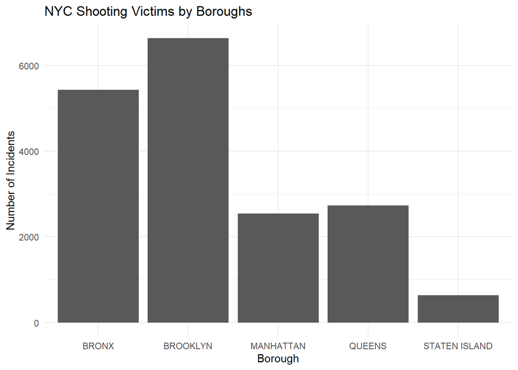

```r
ggplot(df_shootings, aes(x = BORO)) +
  geom_bar() +
  labs(title = "NYC Shooting Victims by Boroughs",
       x = "Borough",
       y = "Number of Incidents") +
  theme_minimal()
```

We can see that Brooklyn is the Borough with the most shooting incidents in this time period.

3. How has shooting incidents changed over time in NYC?

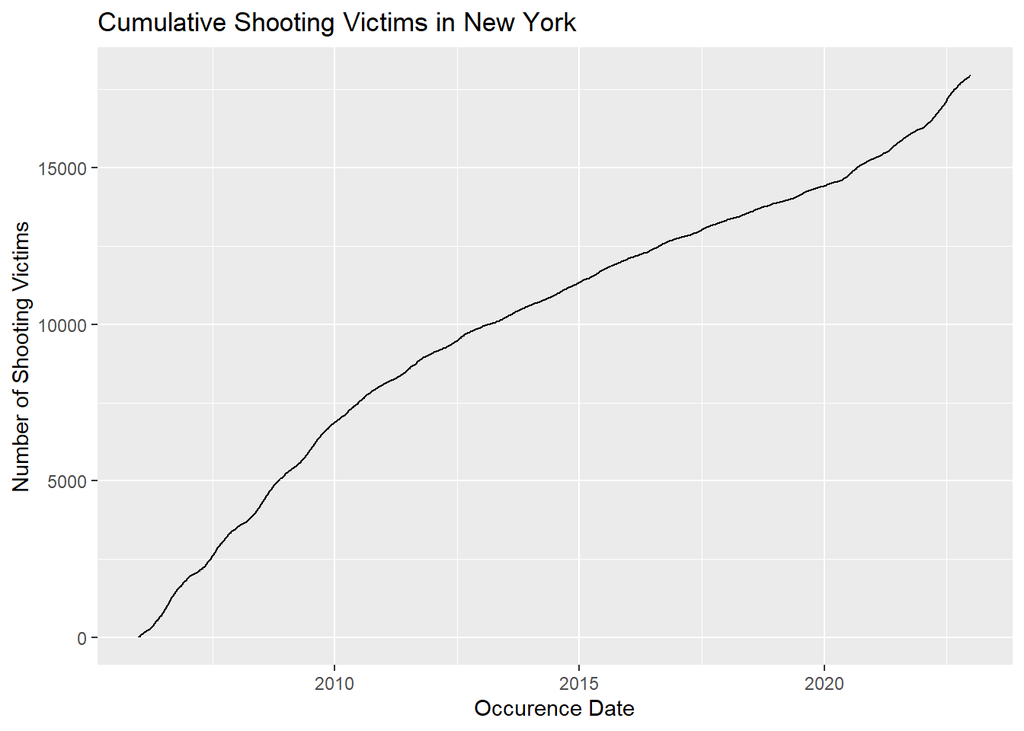

```r
ggplot() +
  geom_line(data=ts_df_shootings, aes(x=OCCUR_DATE, y=cumsum(COUNT))) +
  labs(title = "Cumulative Shooting Victims in New York") +
  labs(y="Number of Shooting Victims", x="Occurence Date")
```

We can see that the slope of the line changes at around 2011-2012 and then again at 2020. Let’s see if all the Boroughs reflex this change in the same manner.

4. How has shooting incidents changed over time in each of the Boroughs?

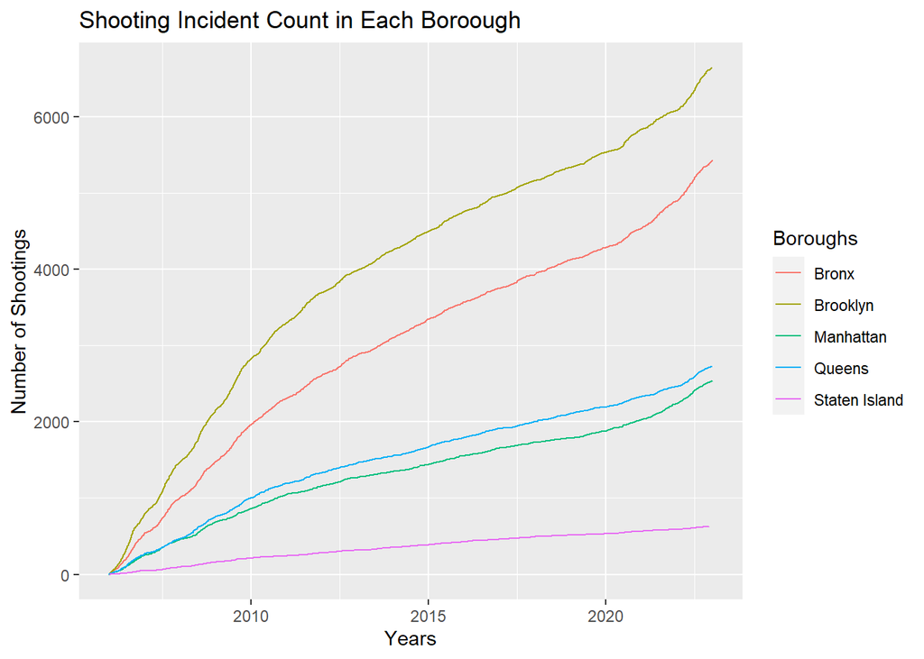

```r
ggplot() +
  geom_line(data=bronx_n, aes(x=OCCUR_DATE, y=cumsum(COUNT), color='Bronx')) +
  geom_line(data=brooklyn_n, aes(x=OCCUR_DATE, y=cumsum(COUNT), color='Brooklyn')) +
  geom_line(data=manhattan_n, aes(x=OCCUR_DATE, y=cumsum(COUNT), color='Manhattan')) +
  geom_line(data=queens_n, aes(x=OCCUR_DATE, y=cumsum(COUNT), color='Queens')) +
  geom_line(data=staten_n, aes(x=OCCUR_DATE, y=cumsum(COUNT), color='Staten Island')) +
  labs(title = "Shooting Incident Count in Each Boroough") +
  labs(y="Number of Shootings", x="Years", color="Boroughs")
```

We can see that all the Boroughs follow a similar trend with the overall picture except Staten Island.

## Modeling

### Transforming

```r
yearly_data <- ts_df_shootings
yearly_data$OCCUR_DATE <- yearly_data$OCCUR_DATE %>% year()
yearly_data <- yearly_data %>% group_by(OCCUR_DATE) %>% summarise(COUNT=n())

brooklyn_yearly <- brooklyn_n
brooklyn_yearly$OCCUR_DATE <- brooklyn_yearly$OCCUR_DATE %>% year()
brooklyn_yearly <- brooklyn_yearly %>% group_by(OCCUR_DATE) %>% summarise(COUNT=n())

staten_yearly <- staten_n
staten_yearly$OCCUR_DATE <- staten_yearly$OCCUR_DATE %>% year()
staten_yearly <- staten_yearly %>% group_by(OCCUR_DATE) %>% summarise(COUNT=n())

summary(brooklyn_yearly)
```

```
##    OCCUR_DATE       COUNT
##  Min.   :2006   Min.   :109.0
##  1st Qu.:2010   1st Qu.:124.0
##  Median :2014   Median :154.0
##  Mean   :2014   Mean   :181.3
##  3rd Qu.:2018   3rd Qu.:237.0
##  Max.   :2022   Max.   :289.0
```

```r
summary(staten_yearly)
```

```
##    OCCUR_DATE       COUNT
##  Min.   :2006   Min.   :14.00
##  1st Qu.:2010   1st Qu.:22.00
##  Median :2014   Median :27.00
##  Mean   :2014   Mean   :26.76
##  3rd Qu.:2018   3rd Qu.:31.00
##  Max.   :2022   Max.   :42.00
```

### Prediction Model

```r
merge_data <- merge(brooklyn_yearly[-1,],staten_yearly[-1,], by="OCCUR_DATE")

mod <- lm(COUNT.y ~ COUNT.x, data = merge_data)

summary(mod)
```

```
##
## Call:
## lm(formula = COUNT.y ~ COUNT.x, data = merge_data)
##
## Residuals:
##      Min       1Q   Median       3Q      Max
## -11.0645  -2.4854   0.9192   1.9248   7.8758
##
## Coefficients:
##             Estimate Std. Error t value Pr(>|t|)
## (Intercept) 10.38283    4.19352   2.476  0.02668 *
## COUNT.x      0.09233    0.02287   4.038  0.00122 **
## ---
## Signif. codes:  0 '***' 0.001 '**' 0.01 '*' 0.05 '.' 0.1 ' ' 1
##
## Residual standard error: 5.144 on 14 degrees of freedom
## Multiple R-squared:  0.538,  Adjusted R-squared:  0.505
## F-statistic:  16.3 on 1 and 14 DF,  p-value: 0.001222
```

[figure not shown]

```r
regs <- merge_data %>% mutate(reg = predict(mod))

regs %>% ggplot() + geom_point(aes(x=COUNT.x,y=COUNT.y,color = "Raw Data")) +
  geom_line(aes(x=COUNT.x,y=reg, color = "Regression")) +
  scale_x_continuous(breaks = pretty(yearly_data$OCCUR_DATE, n = 1)) +
  labs(title = "Correlation between Yearly Shootings
       in Brooklyn and Staten Island") +
  labs(y="Staten Island Yearly Shooting Incidents",
       x="Bronx Yearly Shooting Incidents", color="Legend")
```

## Bias

Bias could stem from inconsistent reporting in certain areas, which may lead to data gaps in some places and an overabundance in others. The data also fail to take into account socioeconomic status and other outside factors like weather or the COVID 19 pandemic. More info on these variables may needed to enhance the conclusions that can be made in this analysis.